# Tasas de Interés Reales

Dada una tasa de interés nominal ($i_t$) y una tasa de inflación esperada ($\pi_t^{e}$), se puede calcular la *Tasa de Interés Real* ($r_t$) de la siguiente forma:

$$r_t = \frac{1+i_t}{1+\pi_t^{e}}-1$$

Para calcular la inflación esperada se utiliza el *Relevamiento de Expectativas del Mercado (REM)* que publica mensualmente el BCRA. Se evaluan dos versiones alternativas de la serie de inflación esperada para los próximos 6 meses:

1. Expectativas puras: inflación esperada en los próximos 6 meses de acuerdo al REM.
2. Expectativas mixtas: Inflación pasada + expectativas. Empalme de los últimos tres meses del Índice de Precios al Consumidor (INDEC, Índice Nacional) con las expectativas de inflación de los próximos 3 meses (REM).

En teoría, la serie de “expectativas puras” debería ser preferible, ya que los agentes toman decisiones hoy en base a lo que esperan para el futuro. Y en lo que esperan para el futuro ya debería estar incorporada la inflación pasada. Si, por algún motivo, se piensa que el indicador de expectativas de inflación no incorpora correctamente la dinámica previa de la inflación, puede ser útil una serie mixta como la que aquí se utiliza.

A continuación, se presenta el gráfico de estas dos series:

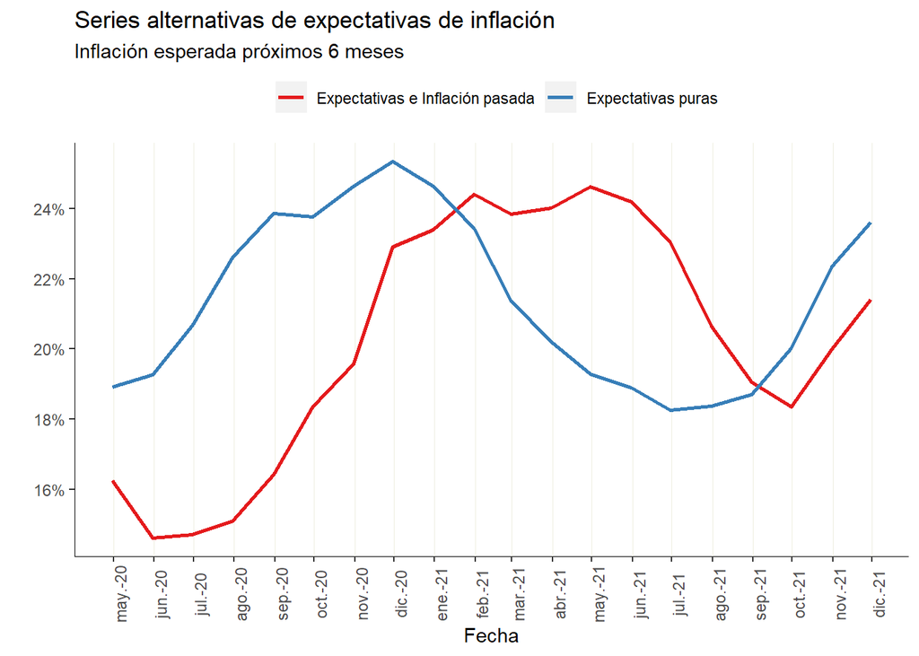

Se observa que la serie de “Expectativas puras” parece anticipar el comportamiento de la otra. Observando el pasado, ¿qué serie ha sido un mejor predictor de la inflación?

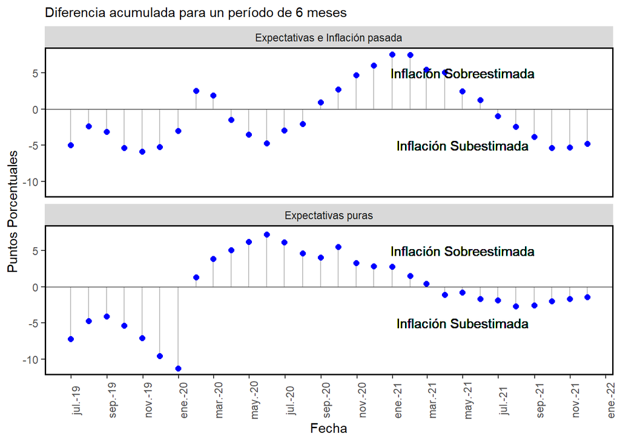

|  | Error absoluto promedio (p.p.) | Desvío Standard |
| --- | --- | --- |
| Expectativas puras | 3.99 | 4.84 |
| Expectativas e Inflación pasada | 3.92 | 4.97 |

Se observa que para ambas series hubo momentos donde subestimaron la inflación y otros donde la sobreestimaron. En promedio, los errores cometidos son similares.

#### Tasas implícitas en estas expectativas de inflación

(Pueden interpretarse como las tasas a 30 días requeridas para que la tasa real sea 0)

|  | Tasa Efectiva Mensual (%) | TNA (%) | TEA (%) |
| --- | --- | --- | --- |
| Expectativas puras | 3.6 | 43.15 | 52.8 |
| Expectativas e Inflación pasada | 3.29 | 39.45 | 47.43 |

A continuación, se presentan cálculos de las tasas reales para distintas tasas de la economía. Si bien el cálculo se realiza con tasas efectivas en un período de 6 meses, se realiza luego la transformación a TNA para facilitar la comparación e interpretación.

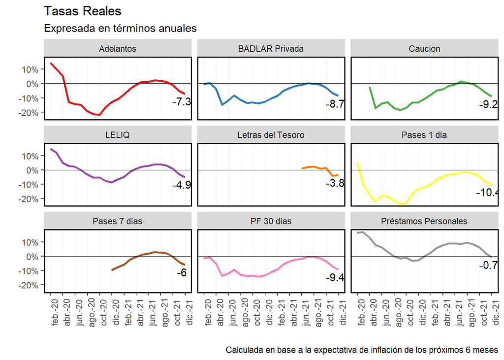

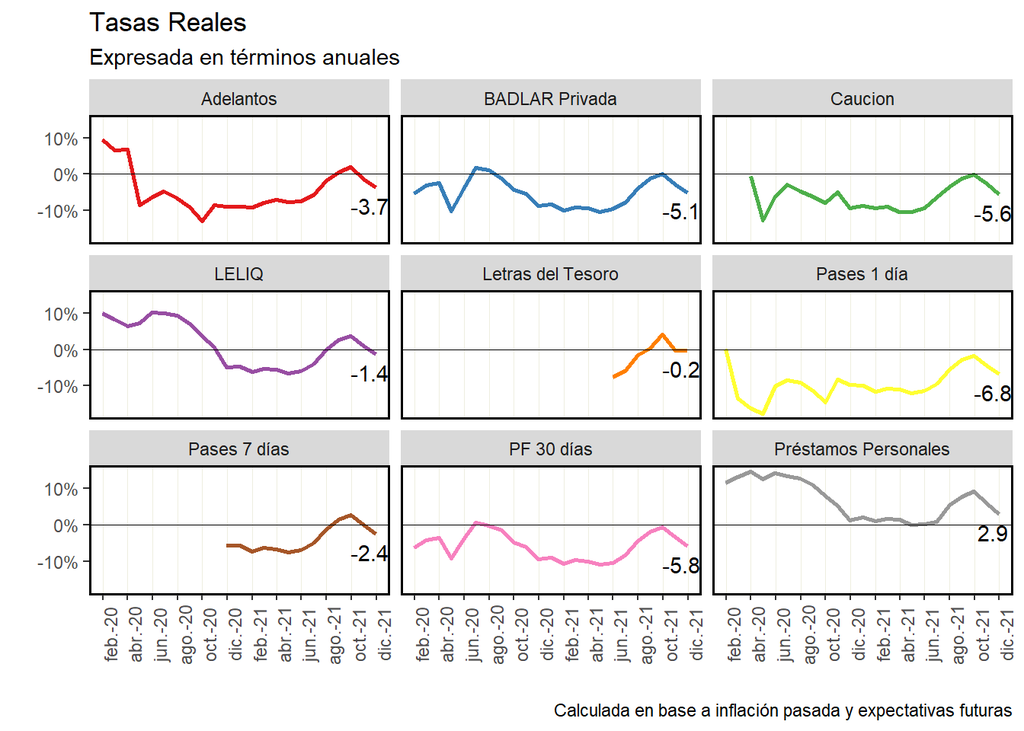

### Costo cuasifiscal de elevar tasas de política monetaria

(Se supone que los stock actuales no se modifican)

| Escenario | TNA | TEA | Tasa Real Anual | Intereses adicionales (mill.$ anuales) |
| --- | --- | --- | --- | --- |
| Aumento del 10% | LELIQ = 41.8 % Pases 7d = 40.2 % Pases 1d = 35.2 % | LELIQ = 50.9 % Pases 7d = 49.2 % Pases 1d = 42.2 % | LELIQ = -1.2 % Pases 7d = -2.4 % Pases 1d = -7 % | 251231 |
| Aumento del 20% | LELIQ = 45.6 % Pases 7d = 43.8 % Pases 1d = 38.4 % | LELIQ = 56.6 % Pases 7d = 54.7 % Pases 1d = 46.8 % | LELIQ = 2.5 % Pases 7d = 1.2 % Pases 1d = -3.9 % | 511343 |
| Aumento del 30% | LELIQ = 49.4 % Pases 7d = 47.5 % Pases 1d = 41.6 % | LELIQ = 62.4 % Pases 7d = 60.4 % Pases 1d = 51.6 % | LELIQ = 6.3 % Pases 7d = 5 % Pases 1d = -0.8 % | 780637 |